# Chemical Treatments on Vegetables

March 18, 2018

## Introduction

### In this project, we will…

- explore data that was collected to gain insight about chemical treatments applied to food crops as fertilizer, insecticides, etc.
- look at the following parameters from USDA QuickStats:
  - Parameter: Survey
  - Sector: Environmental
  - Group: Vegetables
  - Commodity: Vegetables Totals, Vegetables Other, Broccoli, Brussels Sprouts, Cauliflower
- evaluate toxicity measurements of restricted use chemicals on vegetables

## Tidy

- The data was not tidy at first, so we used tidyverse(tidyr and dplyr) to make the data easier to manipulate.
- We separated each column by sector, so that one column doesn't contain multiple pieces of information.
- We also created a table of toxicity measurements (found by taking the average amount that is toxic to a rat on EPA website) and augmented it (left_join) to our original data set

## Toxicity Levels

To find toxicity of restricted use chemicals, we went on the EPA website, and took the amount that would be toxic for a rat, and averaged out these values. We made a barplot to show the restricted use chemicals vs. its measurements.

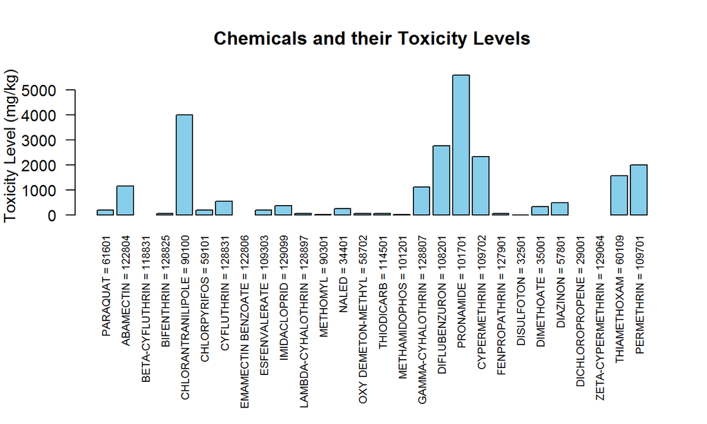

- It is shown that Pronamide has the highest toxicity measure, along with Chlorantranilipole.
- We assume that if a vegetable uses a lot of these chemicals, it would be more harmful for someone to consume.
- Some of the chemicals were missing toxicity measurements: Beta-Cyfluthrin, Emamectin Benzoate, Dichloropropene, and Zeta-Cypermethrin

## Restricted vs Non-Restricted Use Chemicals in Vegetables

We created pie charts for each commodity, to represent the percentage of restricted use chemicals for that vegetable vs the percentage of non-restricted use chemicals. Below, we give an example of Broccoli.

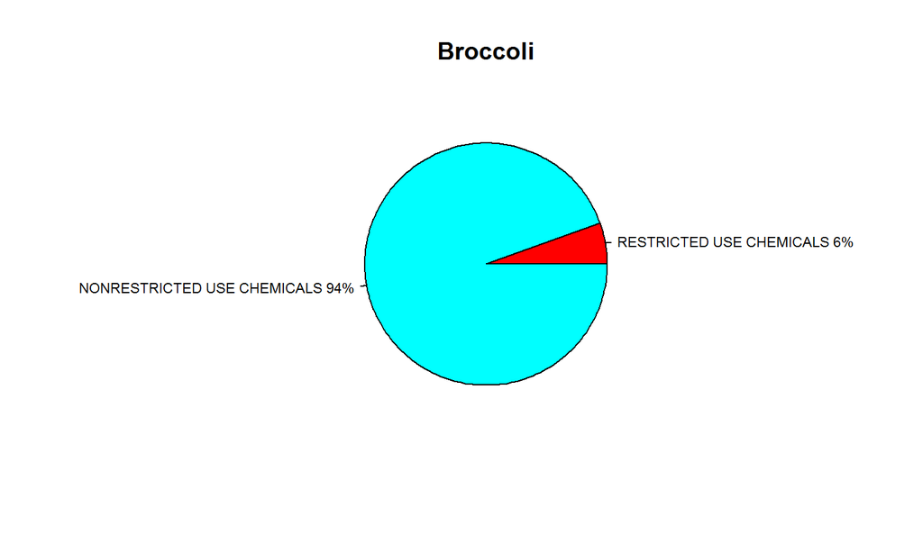

- 6% of broccoli used restricted use chemicals, 5% for cauliflower, but 0% for brussel sprouts and other vegetables
- This shows us that it may be more harmful to consume broccoli and cauliflower than brussel sprouts

## Type of Chemicals in Vegetables

We also created pie charts to see the type of chemicals used for each vegetable. The different types would be either fungicide, herbicide, insecticide, 'other', avoidance, monitoring, prevention, suppresion, or fertilizer, and some with NA. Below, we give an example of broccoli.

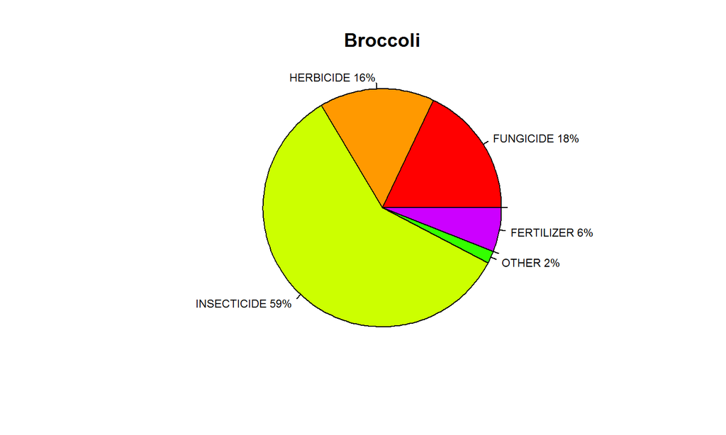

- Broccoli, cauliflower, and brussel sprouts use mainly insecticides
- Broccoli and cauliflower also mainly use herbicide, fungicide, and fertilizer, whereas brussel sprouts only also use fungicide
- These discrepancies may explain why broccoli and cauliflower have higher toxicity level and may be more harmful

## Conclusion

- Pronamide and Chlorantranilipole have the highest toxicity measurements
- Broccoli and Cauliflower have more restricted use chemicals
- Although not certain, it can be inferred that one who consumes more broccoli and cauliflower may be more at risk than one who consumes brussel sprouts
- It may be inferred that herbicide and fertilizer affects these toxicity measurements, seeing that only broccoli and cauliflower use them, unlike brussel sprouts